# Conjoint Analysis Team Project

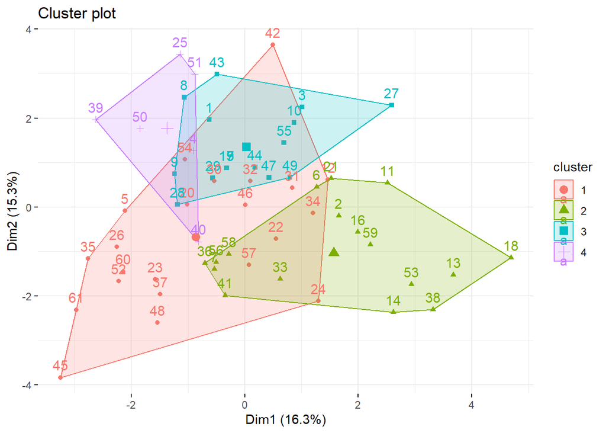

```r
#Cluster plot
fviz_cluster(brkfst_sg_4, brkfst_part_sg, ellipse.type = "convex",
             ggtheme = theme_minimal())
```

Estimating seven clusters:

```r
# estimating clusters
brkfst_sg_7 <- k.means(brkfst_part_sg, n.cluster=7)

# Cluster sizes
prop.table(brkfst_sg_7$size)
```

```
## [1] 0.13114754 0.09836066 0.26229508 0.09836066 0.14754098 0.08196721 0.18032787
```

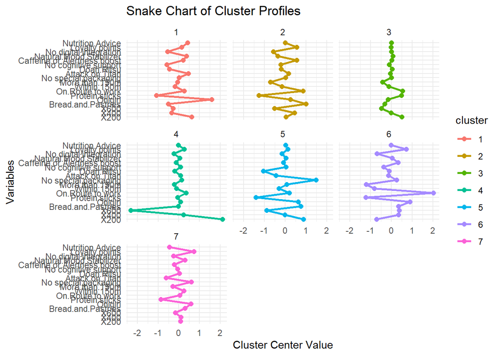

```r
# interpreting clusters
snake.ch2(brkfst_sg_7)
```

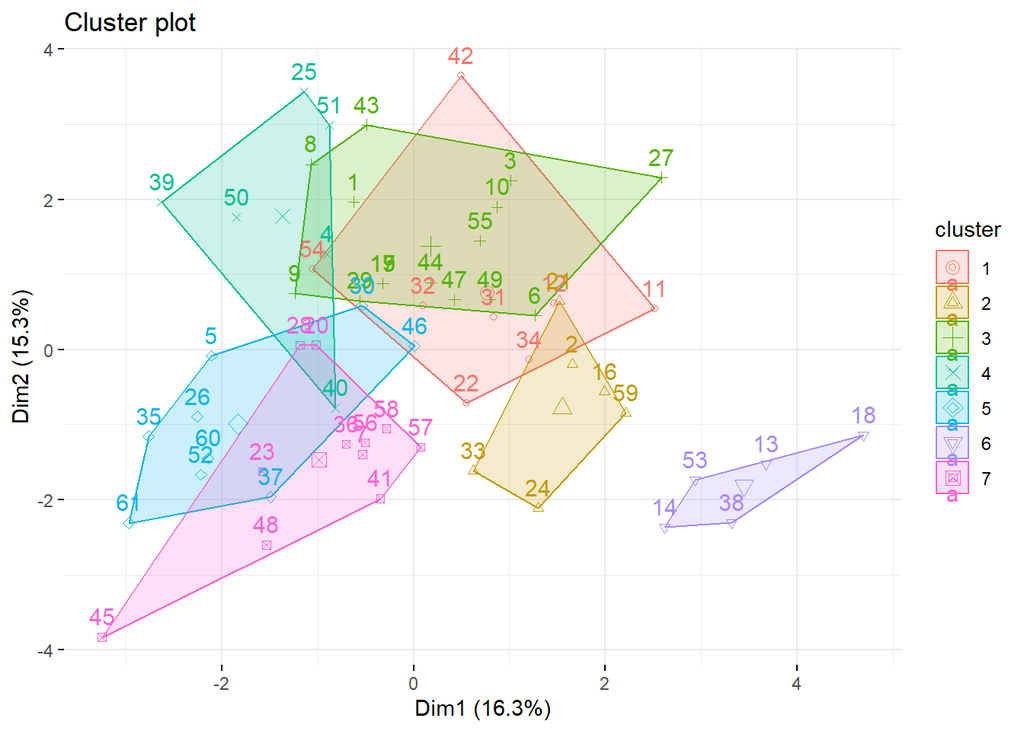

```r
#Cluster plot
fviz_cluster(brkfst_sg_7, brkfst_part_sg, ellipse.type = "convex",
             ggtheme = theme_minimal())
```

### Segment composition

To visualize composition of each cluster - we create a table of each cluster. First we inspect by country.

#### By Country

```r
## segment composition -----
# For analysis: Keep as separate vectors
brkfst_clst <- cbind(brkfst_cmb,
                     cluster = brkfst_sg_4$cluster)

cluster1_names <- brkfst_clst[brkfst_clst$cluster == 1, "country2"]
cluster2_names <- brkfst_clst[brkfst_clst$cluster == 2, "country2"]
cluster3_names <- brkfst_clst[brkfst_clst$cluster == 3, "country2"]
cluster4_names <- brkfst_clst[brkfst_clst$cluster == 4, "country2"]


# For presentation: Create NA-padded data frame
presentation_df <- data.frame(
  cluster1 = c(cluster1_names, rep(NA, length(cluster1_names) - length(cluster1_names))),
  cluster2 = c(cluster2_names, rep(NA, length(cluster1_names) - length(cluster2_names))),
  cluster3 = c(cluster3_names, rep(NA, length(cluster1_names) - length(cluster3_names))),
  cluster4 = c(cluster4_names, rep(NA, length(cluster1_names) - length(cluster4_names)))
)

kable(presentation_df)
```

| cluster1 | cluster2 | cluster3 | cluster4 |
| --- | --- | --- | --- |
| Taiwan | Singapore | Japan | Singapore |
| Romania | China | China | India |
| Bangladesh | Taiwan | China | China |
| India | India | China | Japan |
| Myanmar | Singapore | Taiwan | Thailand |
| Taiwan | Singapore | Singapore | Thailand |
| Japan | Singapore | Singapore | NA |
| Vietnam | Bulgaria | India | NA |
| Malaysia | Bangladesh | China | NA |
| Philippines | Malaysia | China | NA |
| Japan | Japan | China | NA |
| Japan | Japan | Philippines | NA |
| Taiwan | China | Thailand | NA |
| Romania | Vietnam | Vietnam | NA |
| Singapore | Japan | China | NA |
| Japan | Taiwan | China | NA |
| Mongolia | Vietnam | NA | NA |
| Taiwan | NA | NA | NA |
| Korea | NA | NA | NA |
| Philippines | NA | NA | NA |
| South Korea | NA | NA | NA |
| Japan | NA | NA | NA |

#### By Nickname

To view individual names, we have to replace the variable `"country2"` with `"nickname"` in the code below.

```r
# For analysis: Keep as separate vectors
### By Nickname ----
brkfst_clst <- cbind(brkfst_cmb,
                     cluster = brkfst_sg_4$cluster)

cluster1_names <- brkfst_clst[brkfst_clst$cluster == 1, "nickname"]
cluster2_names <- brkfst_clst[brkfst_clst$cluster == 2, "nickname"]
cluster3_names <- brkfst_clst[brkfst_clst$cluster == 3, "nickname"]
cluster4_names <- brkfst_clst[brkfst_clst$cluster == 4, "nickname"]


# For presentation: Create NA-padded data frame
presentation_df <- data.frame(
  cluster1 = c(cluster1_names, rep(NA, length(cluster1_names) - length(cluster1_names))),
  cluster2 = c(cluster2_names, rep(NA, length(cluster1_names) - length(cluster2_names))),
  cluster3 = c(cluster3_names, rep(NA, length(cluster1_names) - length(cluster3_names))),
  cluster4 = c(cluster4_names, rep(NA, length(cluster1_names) - length(cluster4_names)))
)

kable(presentation_df)
```

| cluster1 | cluster2 | cluster3 | cluster4 |
| --- | --- | --- | --- |
| Kimmy | Boon | Matt | Abigail |
| Marius | Hanshu | Yuchen | Hardik |
| Rakib | Kate | Alex | Chuqi |
| Urvi | Sibin | Dana | Ayako |
| Tinttel | Huiyin | Hsiu | Maii |
| Kelvin | jazlyn | reuben | Tae |
| Kohei_Motoike | L | Ray | NA |
| Trang | Paula | Akhil | NA |
| Angeline | Nazmin | su | NA |
| Renzo | Afifah | David | NA |
| Yasutaka Aizawa | Shinya Hashizume | Roui | NA |
| Azusa SAITO | Haruna Hiramatsu | JOE | NA |
| Mei | Jian | Pup | NA |
| Ioan Robert | Quynh | Stacey | NA |
| Jolene | Ogawa Shohei | Eleanor | NA |
| Yuri | Carrie | Lynn | NA |
| Nyamka | Ruby | NA | NA |
| Joseph | NA | NA | NA |
| Yun | NA | NA | NA |
| Ryan | NA | NA | NA |
| Sungchul | NA | NA | NA |
| Takashi | NA | NA | NA |

### Cluster anaylsis

Estimating partworth utilities by cluster:

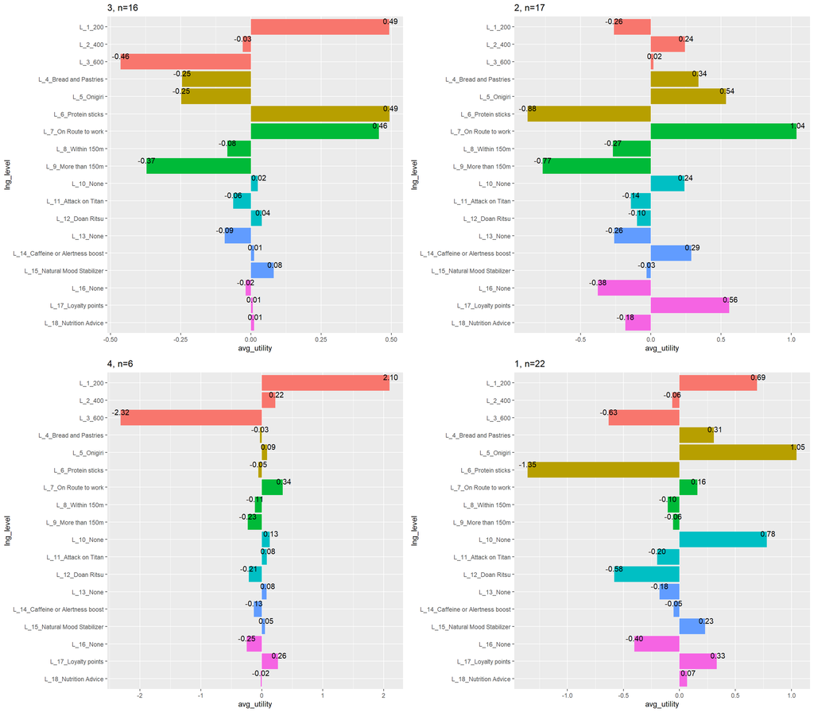

```r
## segment part worth -----
#segmenting part-worth utilities by cluster
plot_list <- list()
var_by = brkfst_clst$cluster
attr_levels <- unique(var_by)

for (i in seq_along(attr_levels)) {

  iter = attr_levels[i]
  n_obs = length(brkfst_part[var_by == iter,1])

  average_utility <- colMeans(brkfst_part[var_by==iter,,drop=FALSE])
  average_utility_df <- data.frame(level = names(average_utility),
                                   avg_utility = average_utility)

  average_utility_df <-
    average_utility_df %>%
    filter(level != "intercept")

  average_utility_df <-
    average_utility_df %>%
    mutate(group =
             c("Price", "Price", "Price",
               "Form", "Form", "Form",
               "PurchaseLocation", "PurchaseLocation", "PurchaseLocation",
               "FunPackaging", "FunPackaging", "FunPackaging",
               "CognitiveSupport", "CognitiveSupport","CognitiveSupport",
               "DigitalIntegration", "DigitalIntegration", "DigitalIntegration"
             )) %>%
    mutate(level_fct = factor(level)) %>%
    mutate(rank = seq.int(1:length(average_utility_df$level))) %>%
    mutate(order_rnk = level, rank) %>%
    mutate(space_char = rep(c("L"), length(average_utility_df$level))) %>%
    unite("lng_level", c("space_char","rank","level"))

  average_utility_df <- average_utility_df %>%
    mutate(rank = seq.int(1:length(average_utility_df$level))) %>%
    mutate(lng_level = as.factor(lng_level)) %>%
    mutate(lng_level = fct_reorder(lng_level, rank )) %>%
    mutate(group_fct = factor(group, levels = c("Price", "Form", "PurchaseLocation",
                                                "FunPackaging", "CognitiveSupport", "DigitalIntegration"
    )))


  plot_list[[i]] <- ggplot(average_utility_df, aes(x=lng_level, y = avg_utility
                                                   ,fill = group_fct
  ))+
    geom_col() +
    coord_flip() +
    scale_x_discrete(limits = rev(levels(average_utility_df$lng_level))) +
    geom_text(aes(label = format(round(avg_utility, 2), nsmall = 2)), vjust = -0.5) +
    ggtitle(paste(iter, n_obs, sep = ", n=")) +
    guides(fill="none")
}
grid.arrange(grobs=plot_list,ncol=2)
```

To visualize relative importance by cluster, we can sort descending:

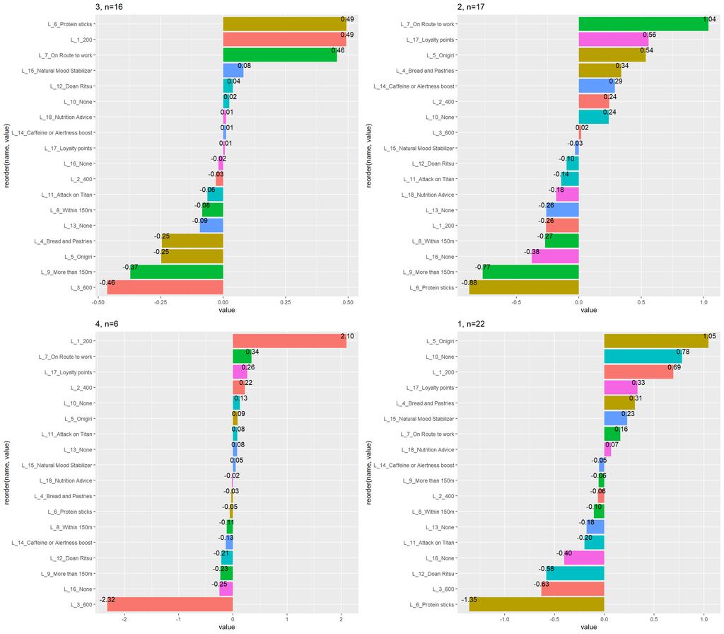

```r
## segment cluster - sorted descending
plot_list <- list()
var_by = brkfst_clst$cluster
attr_levels <- unique(var_by)


for (i in seq_along(attr_levels)) {

  iter = attr_levels[i]
  n_obs = length(brkfst_cmb[var_by == iter,1])

  brkfst_desc_slice <-  brkfst_cmb[var_by == iter,] %>%
    mutate(item_col = iter) %>%
    group_by(item_col) %>%
    summarise_at(vars(L_1_200:`L_18_Nutrition Advice`),
                 mean , na.rm = TRUE) %>%
    pivot_longer(-item_col) %>%
    mutate(group_aggr =
             c("Price", "Price", "Price",
               "Form", "Form", "Form",
               "PurchaseLocation", "PurchaseLocation", "PurchaseLocation",
               "FunPackaging", "FunPackaging", "FunPackaging",
               "CognitiveSupport", "CognitiveSupport","CognitiveSupport",
               "DigitalIntegration", "DigitalIntegration", "DigitalIntegration"
             )) %>%
    mutate(group_aggr =
             factor(group_aggr, levels = c("Price", "Form", "PurchaseLocation",
                                           "FunPackaging", "CognitiveSupport", "DigitalIntegration"
             ))) %>%
    arrange(desc(value)) %>%
    ungroup

  #kable(brkfst_desc_slice)


  plot_list[[i]] <- ggplot(brkfst_desc_slice,
                           aes(x= reorder(name,value), y = value
                               ,fill = group_aggr
                           ))+
    geom_col() +
    coord_flip() +
    #scale_x_discrete(limits = rev(levels(average_utility_df$lng_level))) +
    geom_text(aes(label = format(round(value, 2), nsmall = 2)), vjust = -0.5) +
    ggtitle(paste(iter, n_obs, sep = ", n=")) +
    guides(fill="none")
}
grid.arrange(grobs=plot_list,ncol=2)
```

Finally, computing importance by each cluster:

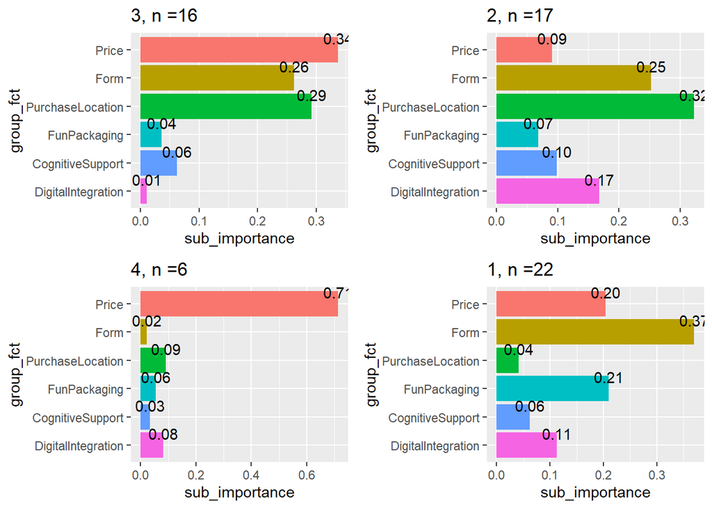

```r
#### importance by cluster
plot_list <- list()
var_by = brkfst_clst$cluster
attr_levels <- unique(var_by)

for (i in seq_along(attr_levels)) {

  iter = attr_levels[i]
  n_obs = length(brkfst_part[var_by == iter,1])

  sub_importance <-
    ca.importance(brkfst_part[var_by == iter,], attribute)

  sub_importance_df <- data.frame(
    sub_importance = sub_importance,
    attribute_txt = names(sub_importance)
  )
  sub_importance_df <- sub_importance_df %>%
    mutate(group_fct = factor(attribute_txt, levels = c("Price", "Form", "PurchaseLocation",
                                                        "FunPackaging", "CognitiveSupport", "DigitalIntegration"
    )))

  plot_list[[i]] <- ggplot(sub_importance_df, aes(x=group_fct, y = sub_importance,
                                                  fill=group_fct)) +
    geom_col() +
    coord_flip() +
    scale_x_discrete(limits = rev(levels(sub_importance_df$group_fct))) +
    geom_text(aes(label = format(round(sub_importance, 2), nsmall = 2)), vjust = -0.5) +
    ggtitle(paste(iter, n_obs, sep = ", n =")) +
    guides(fill="none")
}

grid.arrange(grobs=plot_list,ncol=2)
```

## Trade-off calculation

We first prepare the object for trade-off:

```r
### allocate separate object for all trade-off calculation
average_utility <- colMeans(brkfst_part)
average_utility_df_all <- data.frame(level = names(average_utility),
                                     avg_utility = average_utility)

average_utility_df_all <-
  average_utility_df_all %>%
  filter(level != "intercept")

average_utility_df_all  <-
  average_utility_df_all  %>%
  mutate(group =
           c("Price", "Price", "Price",
             "Form", "Form", "Form",
             "PurchaseLocation", "PurchaseLocation", "PurchaseLocation",
             "FunPackaging", "FunPackaging", "FunPackaging",
             "CognitiveSupport", "CognitiveSupport","CognitiveSupport",
             "DigitalIntegration", "DigitalIntegration", "DigitalIntegration"
           )) %>%
  mutate(level_fct = factor(level)) %>%
  mutate(rank = seq.int(1:length(average_utility_df_all$level))) %>%
  mutate(order_rnk = level, rank) %>%
  mutate(space_char = rep(c("L"), length(average_utility_df_all$level))) %>%
  unite("lng_level", c("space_char","rank","level"))

average_utility_df_all <- average_utility_df_all %>%
  mutate(rank = seq.int(1:length(average_utility_df_all$level))) %>%
  mutate(lng_level = as.factor(lng_level)) %>%
  mutate(lng_level = fct_reorder(lng_level, rank )) %>%
  mutate(group_fct = factor(group, levels = c("Price", "Form", "PurchaseLocation",
                                              "FunPackaging", "CognitiveSupport", "DigitalIntegration"
  )))
```

Subsequently, we can calculate the average value of one monetary utility:

$\frac{¥600 - ¥200}{0.513-(-0.572)}$ = ¥368.85

```r
# average monetary value of 1 utiliy
# linear utility function
util_linear_value <-  (600-200)/
  (average_utility_df_all[average_utility_df_all$lng_level ==
                            "L_1_200",]$avg_utility-
     average_utility_df_all[average_utility_df_all$lng_level ==
                              "L_3_600",]$avg_utility)
util_linear_value
```

```
## [1] 368.8475
```

```r
# piece-wise utility function
util_piecewise_1 <- (600-400)/(average_utility["400"]-average_utility["600"])
util_piecewise_1
```

```
##      400
## 317.0478
```

```r
util_piecewise_2 <- (400-200)/(average_utility["200"]-average_utility["400"])
util_piecewise_2
```

```
##      200
## 440.8789
```

To visualize the trade-off, we can plot:

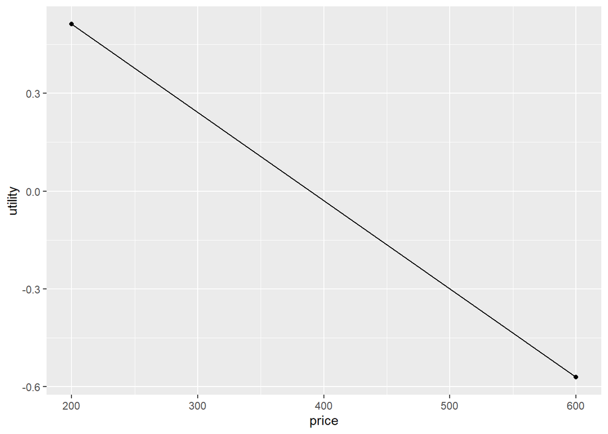

```r
tri_df_points <-
  data.frame(
    price = c(200, 600),
    utility =
      c(average_utility_df_all[average_utility_df_all$lng_level ==
                                 "L_1_200",]$avg_utility,
        average_utility_df_all[average_utility_df_all$lng_level ==
                                 "L_3_600",]$avg_utility)
  )

ggplot(tri_df_points,
       aes(x = price, y = utility)) +
  geom_point() + geom_line()
```

Going from no cognitive support to Caffeine and Alertness boost, the client would be willing to pay more:

```r
# moving from none to caffeine or alertness boost
delta_cognitive_support_none_caffeine <- (average_utility_df_all[average_utility_df_all$lng_level=="L_14_Caffeine or Alertness boost",]$avg_utility -
                                            average_utility_df_all[average_utility_df_all$lng_level=="L_13_None",]$avg_utility) * util_linear_value
delta_cognitive_support_none_caffeine
```

```
## [1] 75.81933
```

Going from no cognitive support to Natural Mood stabilizer, the client would be willing to pay more:

```r
# moving from none to natural mood stabilizers
delta_cognitive_support_none_naturalmood <-
  (average_utility_df_all[average_utility_df_all$lng_level=="L_15_Natural Mood Stabilizer",]$avg_utility -
     average_utility_df_all[average_utility_df_all$lng_level=="L_13_None",]$avg_utility) * util_linear_value
delta_cognitive_support_none_naturalmood
```

```
## [1] 94.01379
```

## Market share prediction

### Commercial considerations

Before deciding on a product launch, it may be useful to review the preferences of the Japanese consumer.

The parthworth for the Japanese consumer:

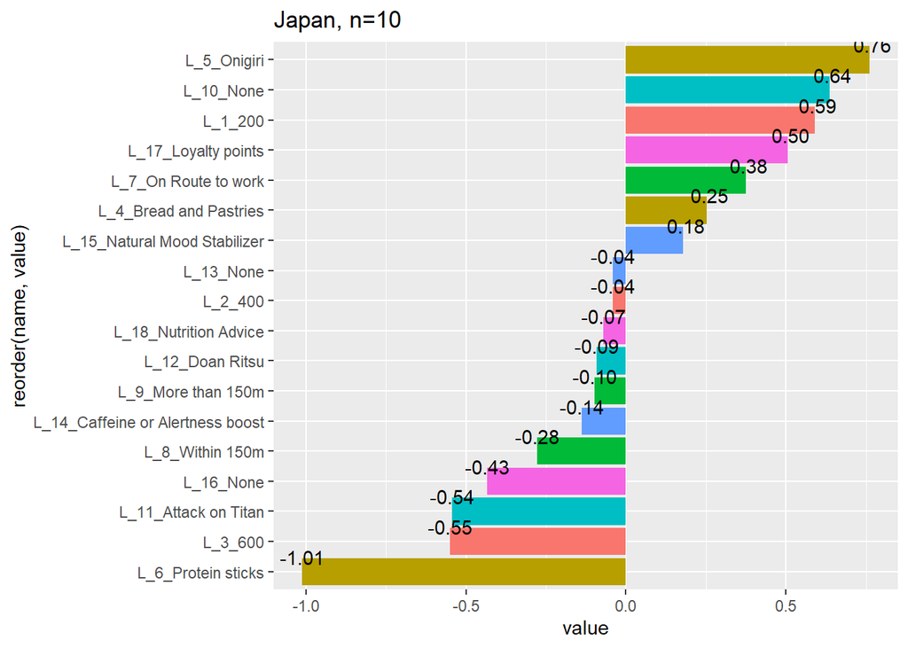

```r
## tastes of the Japanese consumer
## partworth - sorted descending For Japan
iter = "Japan"
n_obs = length(brkfst_cmb[brkfst_cmb$country2 == iter,1])

brkfst_desc_slice <-  brkfst_cmb[brkfst_cmb$country2 == iter,] %>%
  mutate(item_col = iter) %>%
  group_by(item_col) %>%
  summarise_at(vars(L_1_200:`L_18_Nutrition Advice`),
               mean , na.rm = TRUE) %>%
  pivot_longer(-item_col) %>%
  mutate(group_aggr =
           c("Price", "Price", "Price",
             "Form", "Form", "Form",
             "PurchaseLocation", "PurchaseLocation", "PurchaseLocation",
             "FunPackaging", "FunPackaging", "FunPackaging",
             "CognitiveSupport", "CognitiveSupport","CognitiveSupport",
             "DigitalIntegration", "DigitalIntegration", "DigitalIntegration"
           )) %>%
  mutate(group_aggr =
           factor(group_aggr, levels = c("Price", "Form", "PurchaseLocation",
                                         "FunPackaging", "CognitiveSupport", "DigitalIntegration"
           ))) %>%
  arrange(desc(value)) %>%
  ungroup

ggplot(brkfst_desc_slice,
       aes(x= reorder(name,value), y = value
           ,fill = group_aggr
       ))+
  geom_col() +
  coord_flip() +
  #scale_x_discrete(limits = rev(levels(average_utility_df$lng_level))) +
  geom_text(aes(label = format(round(value, 2), nsmall = 2)), vjust = -0.5) +
  ggtitle(paste(iter, n_obs, sep = ", n=")) +
  guides(fill="none")
```

And the importance:

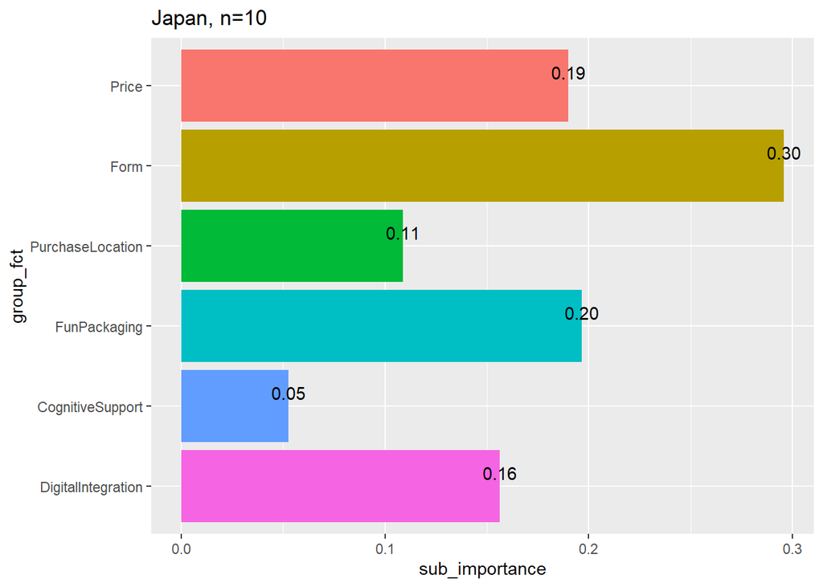

```r
## importance of attributes for the Japanese consumer
#### Japan - importance
iter = "Japan"
var_by = brkfst$country2

n_obs = length(brkfst_part[var_by == iter,1])

sub_importance <-
  ca.importance(brkfst_part[var_by == iter,], attribute)

sub_importance_df <- data.frame(
  sub_importance = sub_importance,
  attribute_txt = names(sub_importance)
)
sub_importance_df <- sub_importance_df %>%
  mutate(group_fct = factor(attribute_txt, levels = c("Price", "Form", "PurchaseLocation",
                                                      "FunPackaging", "CognitiveSupport", "DigitalIntegration"
  )))

ggplot(sub_importance_df, aes(x=group_fct, y = sub_importance,
                              fill=group_fct)) +
  geom_col() +
  coord_flip() +
  scale_x_discrete(limits = rev(levels(sub_importance_df$group_fct))) +
  geom_text(aes(label = format(round(sub_importance, 2), nsmall = 2)), vjust = -0.5) +
  ggtitle(paste(iter, n_obs, sep = ", n=")) +
  guides(fill="none")
```

### Estimation of market share (Logit)

In order to test our potential market share, we benchmark against four existing alternatives:

- the pastrami croissant from Paul Shimbashi
- the 7-Eleven onigiri
- the melonpan at Shimbashi cafe
- the Family Mart protein stick

```r
# Market Prediction
## 5 benchmarks
## Paul shimbashi, pastrami croissant
brkfst_sim <- data.frame(
  Price = c("600"),
  Form = c("Bread and Pastries"),
  PurchaseLocation = c("On Route to work"),
  FunPackaging = c("None"),
  CognitiveSupport = c("None"),
  DigitalIntegration = c("None")
)

# 7-eleven onigiri
brkfst_sim <- rbind(brkfst_sim,
                    c("200","Onigiri","On Route to work","None","None","None"))


# Shimbashi cafe melonpan
brkfst_sim <- rbind(brkfst_sim,
                    c("200","Bread and Pastries","On Route to work","None","None","None"))



# Family Mart protein stick okaki
brkfst_sim <- rbind(brkfst_sim,
                    c("400","Protein sticks","Within 150m","None","None","None"))


# Our own product
brkfst_sim <- rbind(brkfst_sim,
                    c("400","Onigiri","Within 150m","Attack on Titan",
                      "Natural Mood Stabilizer","Loyalty points"))
```

Computing our market share:

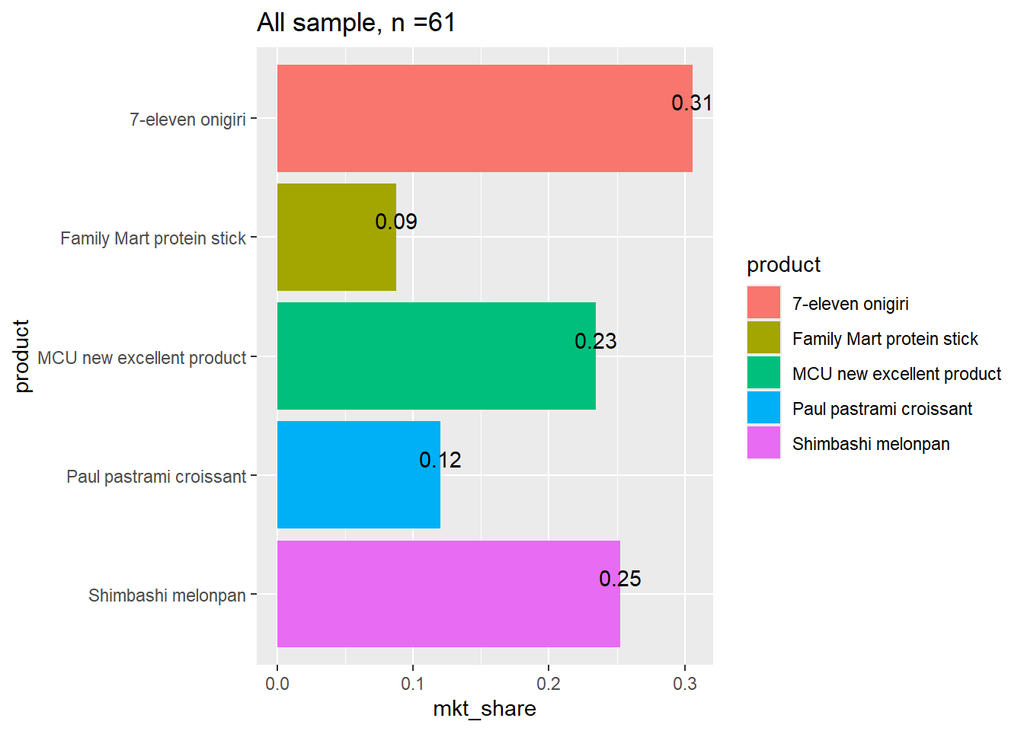

```r
n_obs = length(brkfst$nickname)
iter = "All sample"
market_share <-
  data.frame(product = c("Paul pastrami croissant",
                         "7-eleven onigiri",
                         "Shimbashi melonpan",
                         "Family Mart protein stick",
                         "MCU new excellent product"),
             mkt_share = ca.logit(brkfst_sim, brkfst_part, brkfst_design))

ggplot(market_share, aes(x= product, y = mkt_share,
                         fill=product)) +
  geom_col() +
  coord_flip() +
  scale_x_discrete(limits=rev) +
  geom_text(aes(label = format(round(mkt_share, 2), nsmall = 2)), vjust = -0.5) +
  ggtitle(paste(iter, n_obs, sep = ", n ="))
```

It seems it is not easy to beat the trusted onigiri in Japan.

Computing market share only for Japanese nationality:

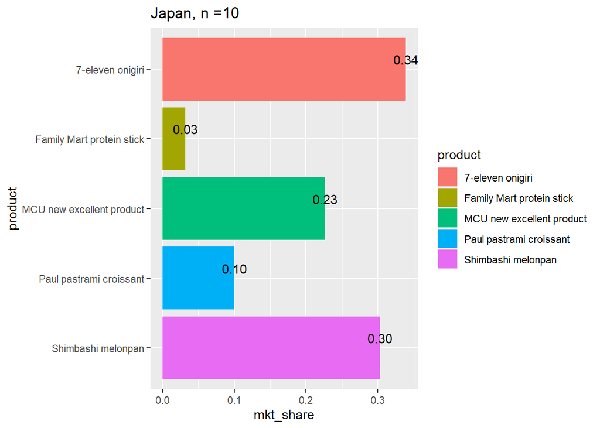

```r
n_obs = length(brkfst[brkfst$country2=="Japan",]$nickname)
iter = "Japan"
market_share_jp <-
  data.frame(product = c("Paul pastrami croissant",
                         "7-eleven onigiri",
                         "Shimbashi melonpan",
                         "Family Mart protein stick",
                         "MCU new excellent product"),
             mkt_share = ca.logit(brkfst_sim,
                                  brkfst_part[brkfst$country2 == "Japan",],
                                  brkfst_design))

ggplot(market_share_jp, aes(x= product, y = mkt_share,
                         fill=product)) +
  geom_col() +
  coord_flip() +
  scale_x_discrete(limits=rev) +
  geom_text(aes(label = format(round(mkt_share, 2), nsmall = 2)), vjust = -0.5) +
ggtitle(paste(iter, n_obs, sep = ", n ="))
```

## Appendix - Various data tables

Code for various tables.

### Partworth by variable

To compute the parthworth by a specific variable, we can run:

```r
## code for tables -----
### for variables
var_by <-  "exercise_per_week_cut"

kable(
  brkfst_cmb %>%
    group_by(group_var = eval(as.name(paste(var_by)))) %>%
    summarise_at(vars(L_1_200:`L_18_Nutrition Advice`),
                 mean , na.rm = TRUE) %>%
    pivot_longer(-group_var) %>%
    pivot_wider(id_cols = name, names_from = "group_var",
                values_from = "value")
)
```

| name | 1-5 times | Never |
| --- | --- | --- |
| L_1_200 | 0.5648571 | 0.3974211 |
| L_2_400 | 0.0333333 | 0.1159474 |
| L_3_600 | -0.5981667 | -0.5133684 |
| L_4_Bread and Pastries | 0.0090714 | 0.4248947 |
| L_5_Onigiri | 0.5631905 | 0.2647368 |
| L_6_Protein sticks | -0.5722143 | -0.6894737 |
| L_7_On Route to work | 0.4747857 | 0.5590526 |
| L_8_Within 150m | -0.1070000 | -0.2323158 |
| L_9_More than 150m | -0.3677143 | -0.3270526 |
| L_10_None | 0.3326190 | 0.4450000 |
| L_11_Attack on Titan | -0.1328571 | -0.0918421 |
| L_12_Doan Ritsu | -0.1998571 | -0.3532632 |
| L_13_None | -0.1348810 | -0.1946316 |
| L_14_Caffeine or Alertness boost | 0.0235476 | 0.1151053 |
| L_15_Natural Mood Stabilizer | 0.1113333 | 0.0794211 |
| L_16_None | -0.2365000 | -0.3736316 |
| L_17_Loyalty points | 0.3478571 | 0.2058421 |
| L_18_Nutrition Advice | -0.1113095 | 0.1677895 |

### Partworth by observations

To investigate specific observations or subgroups we use the `filter()` function, passing the variable and specific observations, as below:

```r
### for specific observations
kable(
  brkfst_cmb %>%
    filter(nickname %in% c("Marius", "Abigail", "Yun", "Matt", "Pup")) %>%
    group_by(nickname) %>%
    summarise_at(vars(L_1_200:`L_18_Nutrition Advice`),
                 mean , na.rm = TRUE) %>%
    pivot_longer(-nickname) %>%
    pivot_wider(id_cols = name, names_from = "nickname",
                values_from = "value")
)
```

| name | Abigail | Marius | Matt | Pup | Yun |
| --- | --- | --- | --- | --- | --- |
| L_1_200 | 1.899 | 1.043 | 0.710 | 1.319 | 0.609 |
| L_2_400 | 0.094 | -0.326 | 0.341 | -0.225 | -0.065 |
| L_3_600 | -1.993 | -0.717 | -1.051 | -1.094 | -0.543 |
| L_4_Bread and Pastries | -0.728 | -0.402 | -0.902 | 0.634 | -0.547 |
| L_5_Onigiri | 0.609 | 0.739 | 0.739 | -1.246 | 1.681 |
| L_6_Protein sticks | 0.120 | -0.337 | 0.163 | 0.612 | -1.134 |
| L_7_On Route to work | 0.337 | 1.141 | 0.308 | 0.786 | -0.105 |
| L_8_Within 150m | 0.057 | -0.396 | -0.729 | -0.268 | -0.172 |
| L_9_More than 150m | -0.393 | -0.746 | 0.421 | -0.518 | 0.278 |
| L_10_None | 0.523 | 0.338 | 0.004 | 0.399 | 0.028 |
| L_11_Attack on Titan | 0.473 | 1.188 | -0.646 | -0.851 | 0.078 |
| L_12_Doan Ritsu | -0.996 | -1.525 | 0.641 | 0.453 | -0.105 |
| L_13_None | -0.486 | -0.430 | 0.404 | -0.446 | 0.167 |
| L_14_Caffeine or Alertness boost | 0.040 | -0.112 | -0.279 | 0.315 | -0.489 |
| L_15_Natural Mood Stabilizer | 0.446 | 0.542 | -0.125 | 0.130 | 0.322 |
| L_16_None | -0.420 | -1.563 | -0.396 | -0.446 | -0.233 |
| L_17_Loyalty points | 0.713 | 1.009 | -0.325 | 0.130 | -0.278 |
| L_18_Nutrition Advice | -0.293 | 0.554 | 0.721 | 0.315 | 0.511 |

### Comparing two countries

To compare two specific countries, for example China and Japan, we can run:

```r
## country comparison
brkfst_cmb %>%
  filter(country2 %in% c("Japan", "China")) %>%
  group_by(country2) %>%
  summarise_at(vars(L_1_200:`L_18_Nutrition Advice`),
               mean , na.rm = TRUE) %>%
  pivot_longer(-country2) %>%
  pivot_wider(id_cols = name, names_from = "country2",
              values_from = "value")
```

```
## # A tibble: 18 × 3
##    name                               China   Japan
##    <chr>                              <dbl>   <dbl>
##  1 L_1_200                           0.590   0.590
##  2 L_2_400                           0.134  -0.0405
##  3 L_3_600                          -0.724  -0.549
##  4 L_4_Bread and Pastries           -0.164   0.252
##  5 L_5_Onigiri                      -0.147   0.761
##  6 L_6_Protein sticks                0.312  -1.01
##  7 L_7_On Route to work              0.593   0.375
##  8 L_8_Within 150m                   0.0195 -0.278
##  9 L_9_More than 150m               -0.612  -0.0977
## 10 L_10_None                         0.0924  0.636
## 11 L_11_Attack on Titan             -0.0485 -0.544
## 12 L_12_Doan Ritsu                  -0.0437 -0.0915
## 13 L_13_None                        -0.0725 -0.0403
## 14 L_14_Caffeine or Alertness boost -0.088  -0.138
## 15 L_15_Natural Mood Stabilizer      0.160   0.178
## 16 L_16_None                        -0.0361 -0.434
## 17 L_17_Loyalty points               0.124   0.505
## 18 L_18_Nutrition Advice            -0.0879 -0.071
```

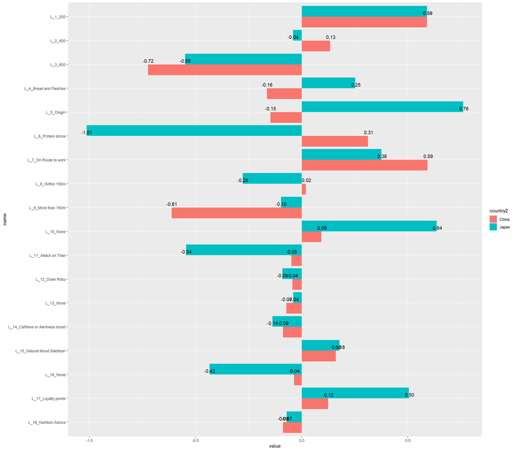

```r
brkfst_cmb_plot <- brkfst_cmb %>%
  filter(country2 %in% c("Japan", "China")) %>%
  group_by(country2) %>%
  summarise_at(vars(L_1_200:`L_18_Nutrition Advice`),
               mean , na.rm = TRUE) %>%
  pivot_longer(-country2) %>%
  # mutate(country2 = factor(country2,
  #                          levels = c("Japan", "China"))) %>%
  mutate(name = factor(name,
                       levels = c("L_1_200",
                                  "L_2_400",
                                  "L_3_600",
                                  "L_4_Bread and Pastries",
                                  "L_5_Onigiri",
                                  "L_6_Protein sticks",
                                  "L_7_On Route to work",
                                  "L_8_Within 150m",
                                  "L_9_More than 150m",
                                  "L_10_None",
                                  "L_11_Attack on Titan",
                                  "L_12_Doan Ritsu",
                                  "L_13_None",
                                  "L_14_Caffeine or Alertness boost",
                                  "L_15_Natural Mood Stabilizer",
                                  "L_16_None",
                                  "L_17_Loyalty points",
                                  "L_18_Nutrition Advice")))

ggplot(brkfst_cmb_plot, aes(x=name , y = value,
                            group = country2, fill=country2)) +
  geom_col(position = "dodge") +
  coord_flip() +
  scale_x_discrete(limits = rev(levels(brkfst_cmb_plot$name))) +
  geom_text(aes(label = format(round(value, 2), nsmall = 2)), vjust = -0.5)
```

```r
#ggtitle(paste(iter, n_obs, sep = ", n =")) +
#guides(fill="none")
```

### The Japanese Consumer

To see the parthworth only for the Japanese subgroup, we run:

```r
brkfst_cmb %>%
  filter(country2 %in% c("Japan")) %>%
  group_by(country2) %>%
  summarise_at(vars(L_1_200:`L_18_Nutrition Advice`),
               mean , na.rm = TRUE) %>%
  pivot_longer(-country2) %>%
  # mutate(country2 = factor(country2,
  #                          levels = c("Japan", "China"))) %>%
  mutate(name = factor(name,
                       levels = c("L_1_200",
                                  "L_2_400",
                                  "L_3_600",
                                  "L_4_Bread and Pastries",
                                  "L_5_Onigiri",
                                  "L_6_Protein sticks",
                                  "L_7_On Route to work",
                                  "L_8_Within 150m",
                                  "L_9_More than 150m",
                                  "L_10_None",
                                  "L_11_Attack on Titan",
                                  "L_12_Doan Ritsu",
                                  "L_13_None",
                                  "L_14_Caffeine or Alertness boost",
                                  "L_15_Natural Mood Stabilizer",
                                  "L_16_None",
                                  "L_17_Loyalty points",
                                  "L_18_Nutrition Advice"))) %>%
  mutate(group_aggr =
           c("Price", "Price", "Price",
             "Form", "Form", "Form",
             "PurchaseLocation", "PurchaseLocation", "PurchaseLocation",
             "FunPackaging", "FunPackaging", "FunPackaging",
             "CognitiveSupport", "CognitiveSupport","CognitiveSupport",
             "DigitalIntegration", "DigitalIntegration", "DigitalIntegration"
           )) %>%
  arrange(desc(value))
```

```
## # A tibble: 18 × 4
##    country2 name                               value group_aggr
##    <chr>    <fct>                              <dbl> <chr>
##  1 Japan    L_5_Onigiri                       0.761  Form
##  2 Japan    L_10_None                         0.636  FunPackaging
##  3 Japan    L_1_200                           0.590  Price
##  4 Japan    L_17_Loyalty points               0.505  DigitalIntegration
##  5 Japan    L_7_On Route to work              0.375  PurchaseLocation
##  6 Japan    L_4_Bread and Pastries            0.252  Form
##  7 Japan    L_15_Natural Mood Stabilizer      0.178  CognitiveSupport
##  8 Japan    L_13_None                        -0.0403 CognitiveSupport
##  9 Japan    L_2_400                          -0.0405 Price
## 10 Japan    L_18_Nutrition Advice            -0.071  DigitalIntegration
## 11 Japan    L_12_Doan Ritsu                  -0.0915 FunPackaging
## 12 Japan    L_9_More than 150m               -0.0977 PurchaseLocation
## 13 Japan    L_14_Caffeine or Alertness boost -0.138  CognitiveSupport
## 14 Japan    L_8_Within 150m                  -0.278  PurchaseLocation
## 15 Japan    L_16_None                        -0.434  DigitalIntegration
## 16 Japan    L_11_Attack on Titan             -0.544  FunPackaging
## 17 Japan    L_3_600                          -0.549  Price
## 18 Japan    L_6_Protein sticks               -1.01   Form
```